# Spread of COVID19 across the World

5/4/2020

## Background

In December 2019, COVID-19 coronavirus was first identified. By March 11, 2020, the World Health Organization (WHO) categorized the COVID-19 outbreak as a pandemic. Currently, on date 4 May 2020, 3.53 million people are infected. Pandemic is spreading all over the world, it becomes literately important to understand about this spread.

## Question: How COVID-19 spreads across the world?

- Geographical distribution
- COVID-19 situation Changes with Time
- What if lockdown

## Original Dataset

```r
confirmed <- read.csv('time_series_covid19_confirmed_global.csv')
confirmed[1, c(1:4, 5,90)]
```

```
##   Province.State Country.Region Lat Long X1.22.20 X4.16.20
## 1                   Afghanistan  33   65        0      840
```

```r
death <- read.csv('time_series_covid19_deaths_global.csv')
death[1, c(1:4, 5,90)]
```

```
##   Province.State Country.Region Lat Long X1.22.20 X4.16.20
## 1                   Afghanistan  33   65        0       30
```

```r
recovered <- read.csv('time_series_covid19_recovered_global.csv')
recovered[1, c(1:4, 5,90)]
```

```
##   Province.State Country.Region Lat Long X1.22.20 X4.16.20
## 1                   Afghanistan  33   65        0       54
```

## COVID-19 Geographical Distribution

East Asia –> West and South Asia –> Europe –> Americas

[interactive chart not shown]

## COVID-19 situation changes with time

[interactive chart not shown]

## COVID-19 situation changes with time

- from 2020-1-26 to 2020-4-16
- Worldwide confirmed cases: 555 —> 2.12 Million
- Averaege growth rate 11%, double every 7 days
- Average death rate 5.5% , higher than Seasonal flu, lower than SARS, MERS

## What if lockdown?

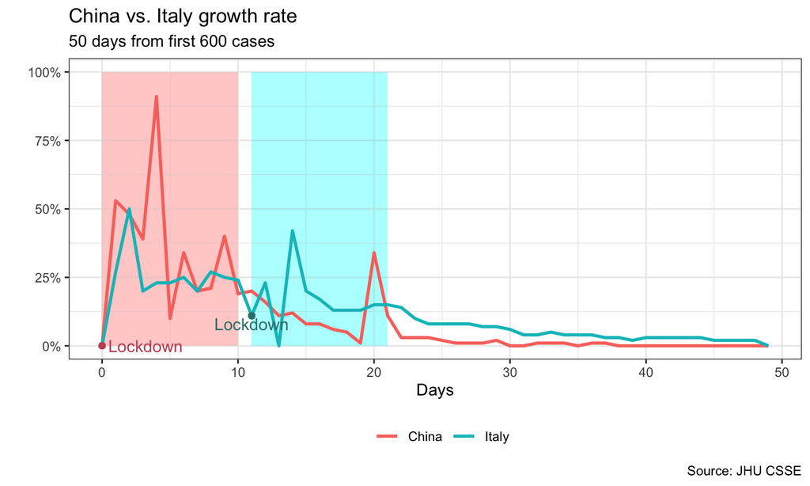

## What if lockdown?

- China: lockdown date 01-23-2020, Day0 in the plot with 643 confirmed case.
- Italy: lockdown date 03-09-2020, Day11 in the plot with 9172 confirmed case.
- Similar growth pattern in shaded areas after the lockdown started, and obvious decrease trend in 11 days.

## Suggestion

- Keep the public informed of the lastest COVID situation
- Keep social distance
- Give support to vulnerable people, such as the elders and homeless people
- Include more data information such as health, population, economy data will better to know how it spread.